# Coursera Machine Learning Project

### Synopsis

This is the Coursera Machine Learning Project Assignement. Data used in this project are sensor measurements from accelerometers on the belt, forearm, arm, and dumbell of 6 participants. They were asked to perform barbell lifts correctly and incorrectly in 5 different ways. Data was recorded in a comma separated file called pml-training.csv.

The goal of this project is to build a model to predict the way the participants performed the exercises using this data.

The output of this assignment is to predict the Classe variable for a series of 20 test samples in a file called pml-testing.csv.

The document covers the steps performed to clean the data, build the model, validate the model, as well as the choices that were made and the assumptions used in the process.

### Read data frames

Download the data sets:

```r
train_name = "train.csv"
test_name = "test.csv"
fileUrl <- "http://d396qusza40orc.cloudfront.net/predmachlearn/pml-training.csv"
download.file(fileUrl, destfile = train_name)
fileUrl <- "http://d396qusza40orc.cloudfront.net/predmachlearn/pml-testing.csv"
download.file(fileUrl, destfile = test_name)
train <- data.frame(read.csv(train_name, header=TRUE))
test_for_prediction <- data.frame(read.csv(test_name, header=TRUE))
dim(train)
```

```
## [1] 19622   160
```

```r
dim(test_for_prediction)
```

```
## [1]  20 160
```

Split the data into a training set to train the model on, and a testing set to test the performanace of the model:

```r
library(caret)
set.seed(100)
inTrain = createDataPartition(train$classe, p = 0.7)[[1]]
training = train[ inTrain,]
testing = train[-inTrain,]
```

### Clean data sets

```r
dim(training)
```

```
## [1] 13737   160
```

```r
#Keep only sensor reading variables
training <- training[,8:ncol(training)]
#Remove columns with NA values from the raw training data set
training <-  training[,colSums(is.na(training)) == 0]
dim(training)
```

```
## [1] 13737    86
```

```r
#Remove near zero variance variables
cols <- nearZeroVar(training, saveMetrics = TRUE)
training <- training[,which(cols$nzv == FALSE)]
dim(training)
```

```
## [1] 13737    53
```

### Build decision trees model with principal component analysis as preProcess option

```r
dec_trees_model <- train(classe~ ., method='rpart', preProcess=c('pca'), data= training)
print(dec_trees_model$finalModel)
```

```
## n= 13737
##
## node), split, n, loss, yval, (yprob)
##       * denotes terminal node
##
## 1) root 13737 9831 A (0.28 0.19 0.17 0.16 0.18)
##   2) PC14>=-0.8833137 12375 8505 A (0.31 0.19 0.19 0.17 0.14)
##     4) PC8< 1.288177 10141 6565 A (0.35 0.17 0.22 0.11 0.14)
##       8) PC12>=-1.408145 9579 6011 A (0.37 0.18 0.23 0.11 0.11) *
##       9) PC12< -1.408145 562  181 E (0.014 0.14 0.0053 0.17 0.68) *
##     5) PC8>=1.288177 2234 1325 D (0.13 0.25 0.048 0.41 0.16) *
##   3) PC14< -0.8833137 1362  599 E (0.026 0.24 0.032 0.14 0.56) *
```

```r
library(rattle)
```

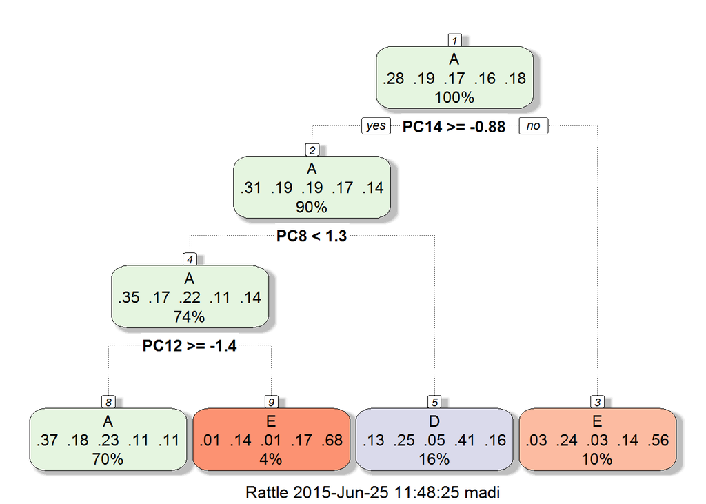

```r
fancyRpartPlot(dec_trees_model$finalModel)
```

### Build random forest model

```r
set.seed(100)
random_forest_model <- train(classe~ ., method='rf', allowParallel=TRUE, data= training)
print(random_forest_model$finalModel)
```

```
##
## Call:
##  randomForest(x = x, y = y, mtry = param$mtry, allowParallel = TRUE)
##                Type of random forest: classification
##                      Number of trees: 500
## No. of variables tried at each split: 27
##
##         OOB estimate of  error rate: 0.82%
## Confusion matrix:
##      A    B    C    D    E class.error
## A 3898    5    2    0    1 0.002048131
## B   19 2629    8    2    0 0.010910459
## C    0   15 2373    8    0 0.009599332
## D    0    2   30 2217    3 0.015541741
## E    0    3    5    9 2508 0.006732673
```

### Cross validation and out of sample error

This section shows that the random forest model predicts the outcome of the classe variable more accurately than the decsion tree model.

```r
#Out of sample error for the decision trees model
mean(predict(dec_trees_model, testing) != testing$classe) * 100
```

```
## [1] 59.66015
```

```r
#Out of sample error for the random forest model
mean(predict(random_forest_model, testing) != testing$classe) * 100
```

```
## [1] 0.6287171
```

```r
#Look at the variable importance for the random forest model
varImp(random_forest_model, useModel=TRUE)
```

```
## rf variable importance
##
##   only 20 most important variables shown (out of 52)
##
##                      Overall
## roll_belt             100.00
## pitch_forearm          60.48
## yaw_belt               56.65
## magnet_dumbbell_z      45.39
## pitch_belt             45.14
## magnet_dumbbell_y      44.22
## roll_forearm           43.31
## accel_dumbbell_y       24.61
## accel_forearm_x        17.66
## magnet_dumbbell_x      17.31
## roll_dumbbell          16.92
## magnet_belt_z          15.71
## magnet_belt_y          14.94
## accel_dumbbell_z       14.22
## magnet_forearm_z       13.98
## total_accel_dumbbell   13.34
## accel_belt_z           12.89
## yaw_arm                10.94
## gyros_belt_z           10.77
## magnet_belt_x          10.15
```

### Predict values using the best model selected

```r
#Use random forest model to predict the outcome of the 20 test cases for submission
predicted_outcomes <- predict(random_forest_model, newdata = test_for_prediction)
predicted_outcomes
```

```
##  [1] B A B A A E D B A A B C B A E E A B B B
## Levels: A B C D E
```